# EZR

Sandra Erdmann

20 December 2018

## El Zonte Rockpools

```
(1) Which rockpool traits determine the absence and / or presence of fish in the rockpools?
(2) Which rockpools traits determine the abundance of fish in the rockpools?
(3) Which rockpool traits determine species richness in the rockpools?

Rockpool traits measured: size, shape, topography, surface area, volume, substrate
```

Variables include rockpool traits, response variable is presence or absence (fish), abundance and species richness.

```
(1) run a binomial model
(2) run a model
(3) run a model
```

### Explore dataset

```r
library(emmeans)
```

```r
library(ggplot2)
library(ggfortify)
library(vegan)
library(car)
library(tidyverse)
ezr<-read.csv('C:/Users/admin/Desktop/Peces el zonte/EZR1.csv', strip.white=T)
head(ezr)
```

```
##   pool species tl  dep    wid  leng per  vol savr  pevr fish sand rock peb
## 1    1      NF ND 3.00  23.33 21.67  80 0.02 3.33 52.75   NO   45   55   0
## 2    2      NF ND 8.67  18.33 41.67 120 0.07 1.15 18.13   NO   60   40   0
## 3    3      NF ND 4.67 113.33 33.33 370 0.18 2.14 20.99   NO   75   25   0
## 4    4      NF ND 4.67  41.67 21.67 130 0.04 2.14 30.86   NO   50   40  10
## 5    5      NF ND 5.00  16.67 29.33  75 0.02 2.00 30.68   NO   80   20   0
## 6    6      NF ND 2.00  26.67 23.33  76 0.01 5.00 61.07   NO   95    5   0
##   alg  rug  rugp height OS RS BA Abundance Richness
## 1   0 1.03 2.913  135.0 ND ND ND         0        0
## 2   0 1.03 2.913  134.5 ND ND ND         0        0
## 3   0 1.10 9.091  137.5 ND ND ND         0        0
## 4   0 1.07 6.542  137.0 ND ND ND         0        0
## 5   0 1.00 0.000  136.0 ND ND ND         0        0
## 6   0 1.00 0.000  135.0 ND ND ND         0        0
```

```r
summary(ezr)
```

```
##       pool    species  tl          dep             wid
##  Min.   : 1   NF:27   ND:45   Min.   : 2.00   Min.   : 15.67
##  1st Qu.:12   SF:18           1st Qu.: 4.67   1st Qu.: 30.00
##  Median :23                   Median :13.33   Median : 36.67
##  Mean   :23                   Mean   :18.70   Mean   : 55.88
##  3rd Qu.:34                   3rd Qu.:24.67   3rd Qu.: 66.67
##  Max.   :45                   Max.   :71.00   Max.   :221.67
##
##       leng             per              vol              savr
##  Min.   : 15.00   Min.   :  65.0   Min.   : 0.010   Min.   :0.14
##  1st Qu.: 30.00   1st Qu.: 120.0   1st Qu.: 0.070   1st Qu.:0.41
##  Median : 56.67   Median : 260.0   Median : 0.320   Median :0.75
##  Mean   : 82.46   Mean   : 348.9   Mean   : 1.801   Mean   :1.29
##  3rd Qu.:133.33   3rd Qu.: 446.0   3rd Qu.: 1.240   3rd Qu.:2.14
##  Max.   :293.33   Max.   :1630.0   Max.   :22.090   Max.   :5.00
##
##       pevr       fish         sand            rock             peb
##  Min.   : 0.66   NO:27   Min.   : 0.00   Min.   :  5.00   Min.   : 0.000
##  1st Qu.: 3.02   SI:18   1st Qu.:15.00   1st Qu.: 25.00   1st Qu.: 0.000
##  Median : 7.34           Median :35.00   Median : 40.00   Median : 5.000
##  Mean   :14.70           Mean   :39.82   Mean   : 47.07   Mean   : 9.333
##  3rd Qu.:20.99           3rd Qu.:65.00   3rd Qu.: 60.00   3rd Qu.:10.000
##  Max.   :77.29           Max.   :95.00   Max.   :100.00   Max.   :50.000
##
##       alg              rug             rugp            height       OS
##  Min.   : 0.000   Min.   :1.000   Min.   : 0.000   Min.   : 30.0   ND:45
##  1st Qu.: 0.000   1st Qu.:1.030   1st Qu.: 2.913   1st Qu.:110.0
##  Median : 0.000   Median :1.100   Median : 9.091   Median :131.0
##  Mean   : 3.889   Mean   :1.108   Mean   : 9.211   Mean   :122.3
##  3rd Qu.: 5.000   3rd Qu.:1.170   3rd Qu.:14.530   3rd Qu.:136.5
##  Max.   :40.000   Max.   :1.330   Max.   :24.812   Max.   :145.0
##
##   RS      BA       Abundance         Richness
##  ND:45   ND:45   Min.   :  0.00   Min.   :0.000
##                  1st Qu.:  0.00   1st Qu.:0.000
##                  Median :  0.00   Median :0.000
##                  Mean   :  9.31   Mean   :1.119
##                  3rd Qu.:  8.75   3rd Qu.:2.000
##                  Max.   :139.00   Max.   :8.000
##                  NA's   :3        NA's   :3
```

Dataset contains some zeros for sand, peb, alg and rugp.

```r
str(ezr)
```

```
## 'data.frame':    45 obs. of  23 variables:
##  $ pool     : int  1 2 3 4 5 6 7 8 9 10 ...
##  $ species  : Factor w/ 2 levels "NF","SF": 1 1 1 1 1 1 1 1 1 1 ...
##  $ tl       : Factor w/ 1 level "ND": 1 1 1 1 1 1 1 1 1 1 ...
##  $ dep      : num  3 8.67 4.67 4.67 5 ...
##  $ wid      : num  23.3 18.3 113.3 41.7 16.7 ...
##  $ leng     : num  21.7 41.7 33.3 21.7 29.3 ...
##  $ per      : int  80 120 370 130 75 76 65 110 77 446 ...
##  $ vol      : num  0.02 0.07 0.18 0.04 0.02 0.01 0.02 0.08 0.02 0.52 ...
##  $ savr     : num  3.33 1.15 2.14 2.14 2 5 2.5 0.97 2.14 0.86 ...
##  $ pevr     : num  52.8 18.1 21 30.9 30.7 ...
##  $ fish     : Factor w/ 2 levels "NO","SI": 1 1 1 1 1 1 1 1 1 1 ...
##  $ sand     : int  45 60 75 50 80 95 45 30 85 70 ...
##  $ rock     : int  55 40 25 40 20 5 20 40 10 15 ...
##  $ peb      : int  0 0 0 10 0 0 35 30 5 15 ...
##  $ alg      : int  0 0 0 0 0 0 0 0 0 0 ...
##  $ rug      : num  1.03 1.03 1.1 1.07 1 1 1 1.17 1.03 1.07 ...
##  $ rugp     : num  2.91 2.91 9.09 6.54 0 ...
##  $ height   : num  135 134 138 137 136 ...
##  $ OS       : Factor w/ 1 level "ND": 1 1 1 1 1 1 1 1 1 1 ...
##  $ RS       : Factor w/ 1 level "ND": 1 1 1 1 1 1 1 1 1 1 ...
##  $ BA       : Factor w/ 1 level "ND": 1 1 1 1 1 1 1 1 1 1 ...
##  $ Abundance: int  0 0 0 0 0 0 0 0 0 0 ...
##  $ Richness : int  0 0 0 0 0 0 0 0 0 0 ...
```

```
int = integral
num = numeric
fctr = factor

tl = total length
savr = surface area volume ratio
pevr = perimetry volume ratio
rugp = rugosity proportion
```

Not neccessary for the following analysis are:

```
tl
OS
RS
BA
```

To simplify further analysis, I will exclude these columns:

```r
ezr<- select(ezr, -tl,-OS, -RS, -BA, -species)
```

```r
head(ezr)
```

```
##   pool  dep    wid  leng per  vol savr  pevr fish sand rock peb alg  rug
## 1    1 3.00  23.33 21.67  80 0.02 3.33 52.75   NO   45   55   0   0 1.03
## 2    2 8.67  18.33 41.67 120 0.07 1.15 18.13   NO   60   40   0   0 1.03
## 3    3 4.67 113.33 33.33 370 0.18 2.14 20.99   NO   75   25   0   0 1.10
## 4    4 4.67  41.67 21.67 130 0.04 2.14 30.86   NO   50   40  10   0 1.07
## 5    5 5.00  16.67 29.33  75 0.02 2.00 30.68   NO   80   20   0   0 1.00
## 6    6 2.00  26.67 23.33  76 0.01 5.00 61.07   NO   95    5   0   0 1.00
##    rugp height Abundance Richness
## 1 2.913  135.0         0        0
## 2 2.913  134.5         0        0
## 3 9.091  137.5         0        0
## 4 6.542  137.0         0        0
## 5 0.000  136.0         0        0
## 6 0.000  135.0         0        0
```

pool should be a factor, not an integral. So we will change that:

```r
mutate(ezr, pool=as.factor(pool))
```

```
##    pool   dep    wid   leng  per   vol savr  pevr fish sand rock peb alg
## 1     1  3.00  23.33  21.67   80  0.02 3.33 52.75   NO   45   55   0   0
## 2     2  8.67  18.33  41.67  120  0.07 1.15 18.13   NO   60   40   0   0
## 3     3  4.67 113.33  33.33  370  0.18 2.14 20.99   NO   75   25   0   0
## 4     4  4.67  41.67  21.67  130  0.04 2.14 30.86   NO   50   40  10   0
## 5     5  5.00  16.67  29.33   75  0.02 2.00 30.68   NO   80   20   0   0
## 6     6  2.00  26.67  23.33   76  0.01 5.00 61.07   NO   95    5   0   0
## 7     7  4.00  26.67  15.00   65  0.02 2.50 40.63   NO   45   20  35   0
## 8     8 10.33  33.33  23.33  110  0.08 0.97 13.69   NO   30   40  30   0
## 9     9  4.67  24.67  19.67   77  0.02 2.14 34.01   NO   85   10   5   0
## 10   10 11.67  33.33 133.33  446  0.52 0.86  8.60   NO   70   15  15   0
## 11   11 11.33  26.00  66.67   80  0.20 0.88  4.07   NO   75   20   5   0
## 12   12 13.33  26.67 156.67  440  0.56 0.75  7.90   NO   85   15   0   0
## 13   13 27.33  39.67  21.33  122  0.23 0.37  5.27   NO   75   25   0   0
## 14   14 23.67  33.33 156.67  464  1.24 0.42  3.75   SI   30   45  15  10
```

[output cut: 77 more lines]

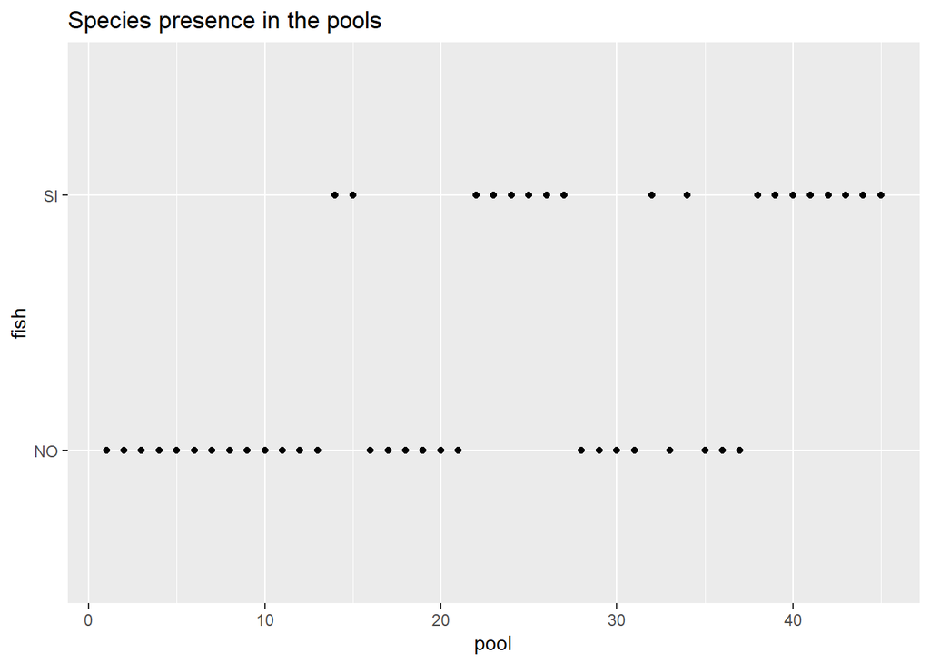

```r
ggplot(ezr, aes(x=pool, y=fish)) +
  geom_point(aes(x=pool, y=fish)) +
       ggtitle("Species presence in the pools")
```

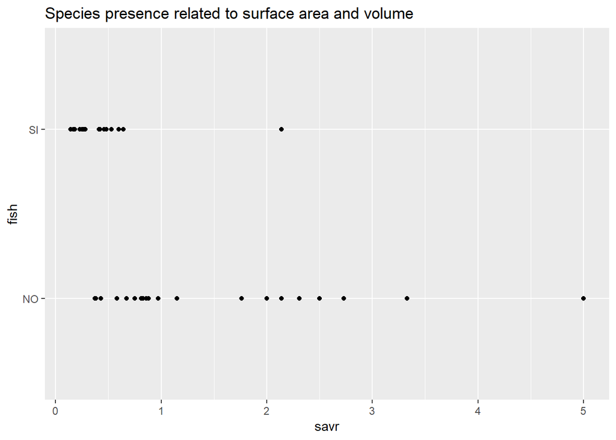

```r
ggplot(ezr, aes(x=savr, y=fish)) +
  geom_point(aes(x=savr, y=fish)) +
       ggtitle("Species presence related to surface area and volume")
```

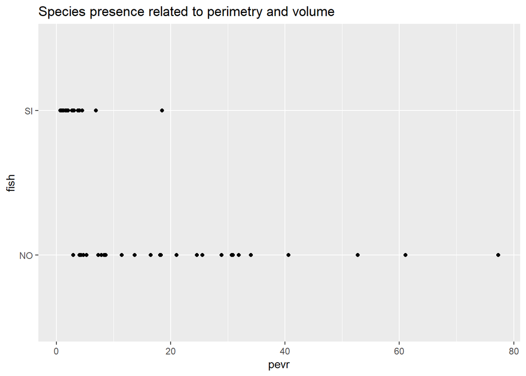

```r
ggplot(ezr, aes(x=pevr, y=fish)) +
  geom_point(aes(x=pevr, y=fish)) +
       ggtitle("Species presence related to perimetry and volume")
```

Conclusion: If the surface area - volume and the perimetry - volume ratio is small, the presence of fish is more likely.

Normality?

Boxplot

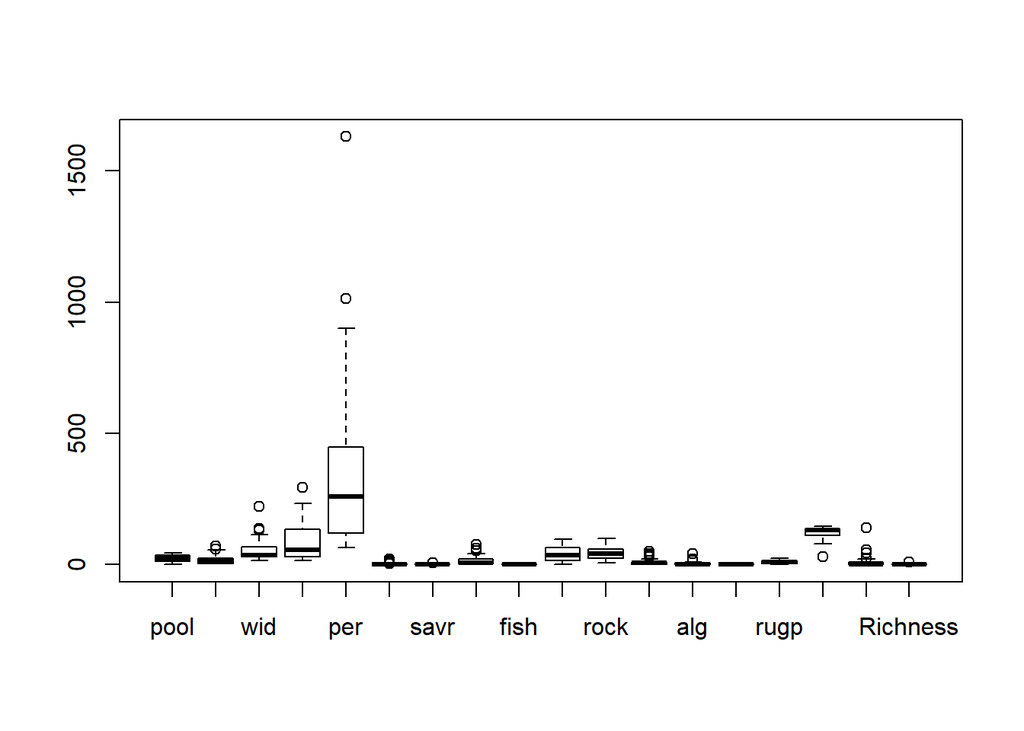

```r
boxplot(ezr)
```

Histogram

```r
# first row, then column
par(mfrow=c(2,3))
attach(ezr)
```

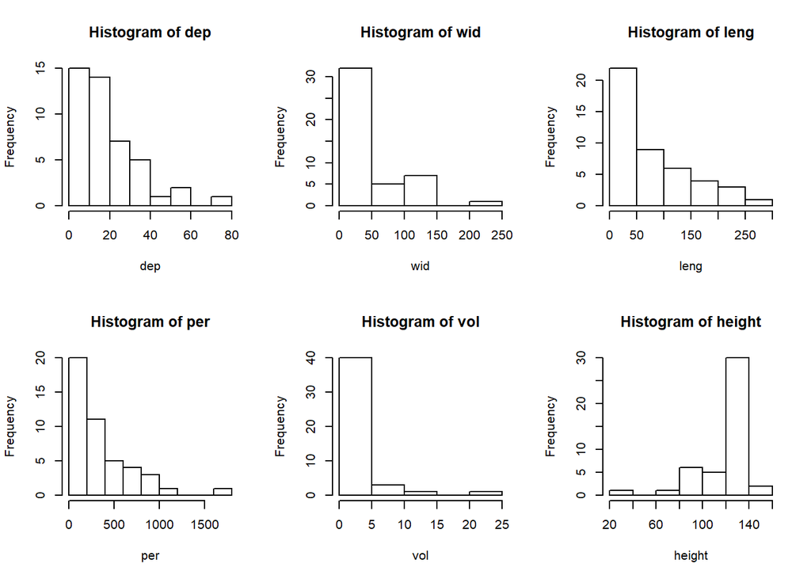

```r
hist(dep)
hist(wid)
hist(leng)
hist(per)
hist(vol)
hist(height)
```

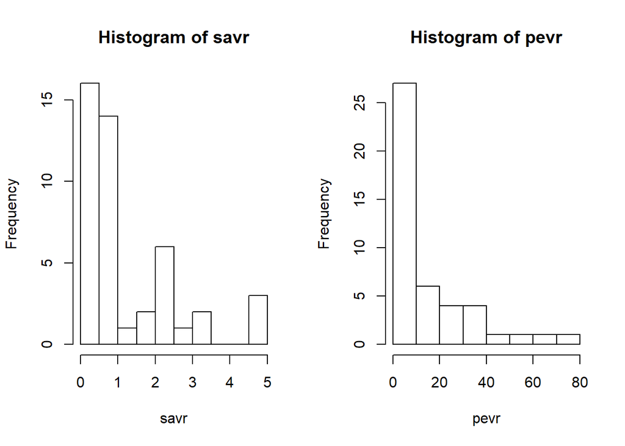

```r
par(mfrow=c(1,2))
hist(savr)
hist(pevr)
```

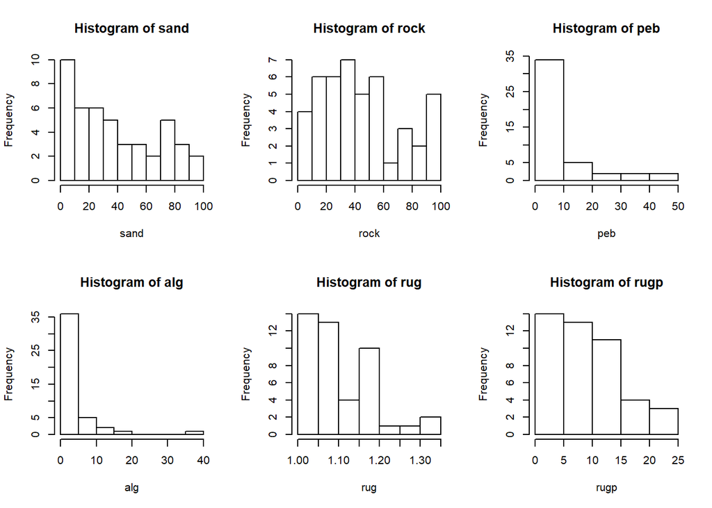

```r
par(mfrow=c(2,3))
hist(sand)
hist(rock)
hist(peb)
hist(alg)
hist(rug)
hist(rugp)
```

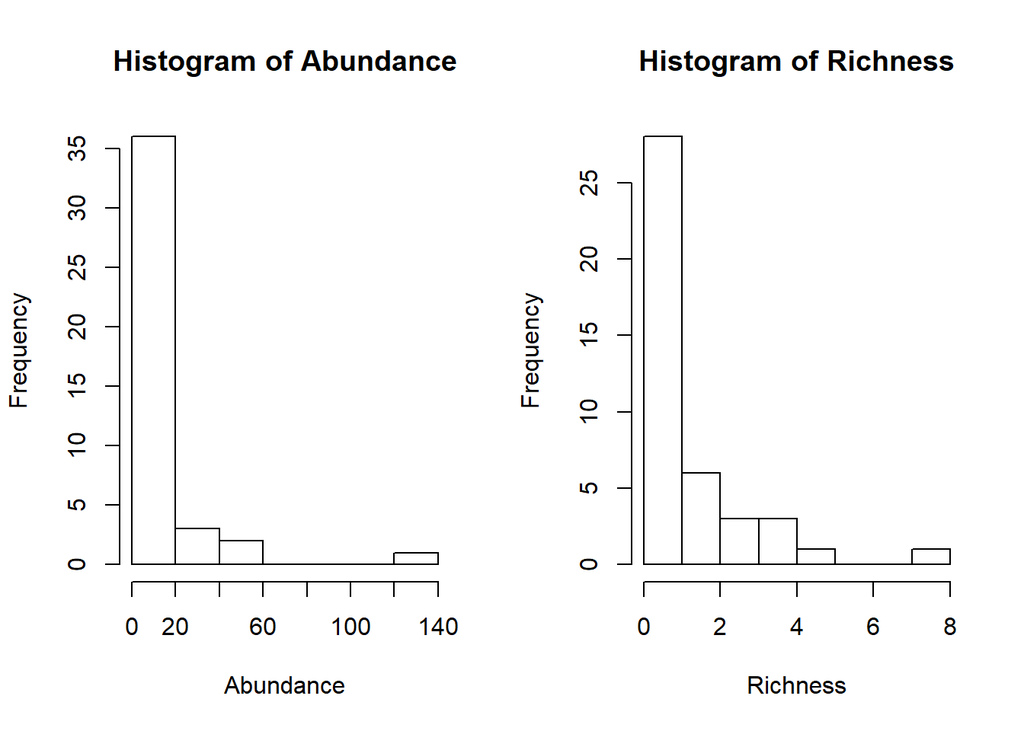

```r
par(mfrow=c(1,2))
hist(Abundance)
hist(Richness)
```

Conclusion: data is not normal. log transform.

```r
# first row, then column
par(mfrow=c(2,3))
attach(ezr)
```

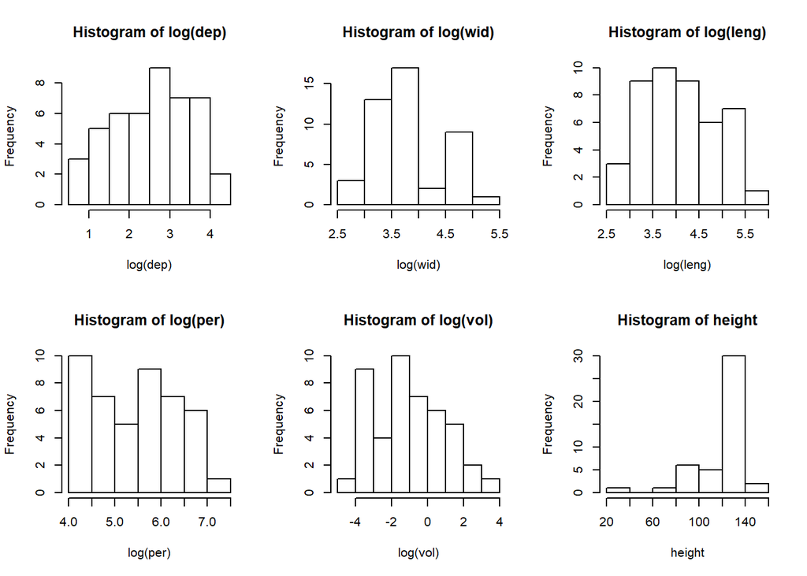

```r
hist(log(dep))
hist(log(wid))
hist(log(leng))
hist(log(per))
hist(log(vol))
hist(height)
```

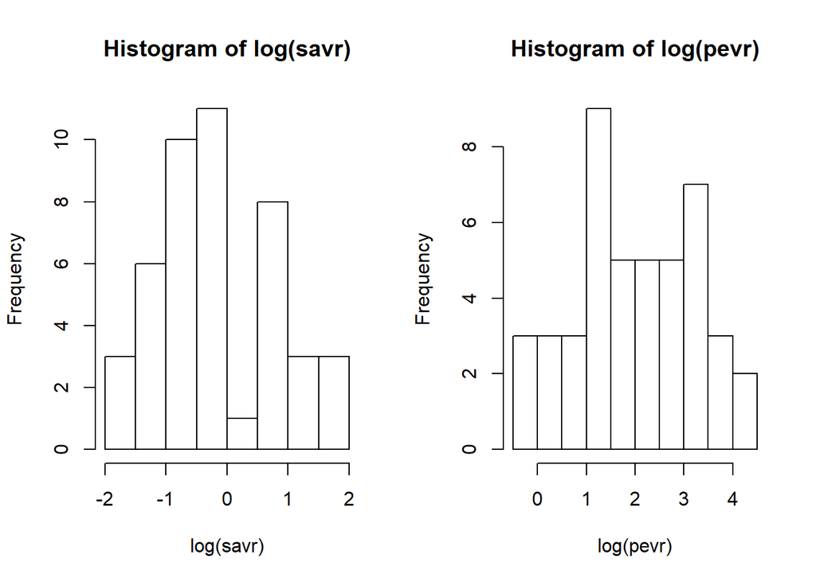

```r
par(mfrow=c(1,2))
hist(log(savr))
hist(log(pevr))
```

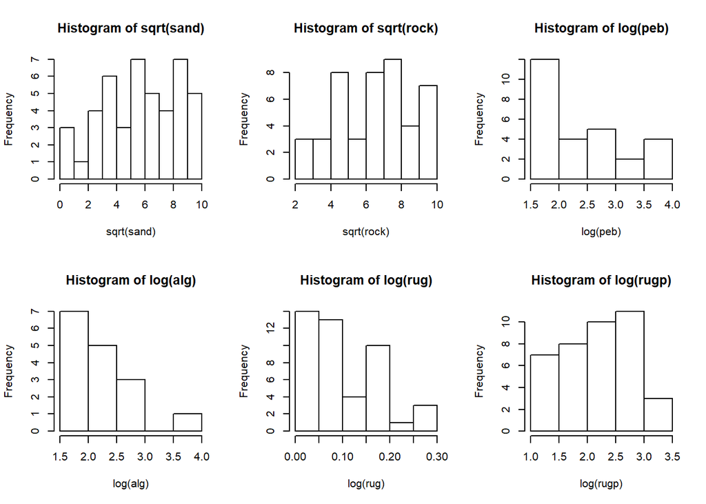

```r
par(mfrow=c(2,3))
hist(sqrt(sand))
hist(sqrt(rock))
hist(log(peb))
hist(log(alg))
hist(log(rug))
hist(log(rugp))
```

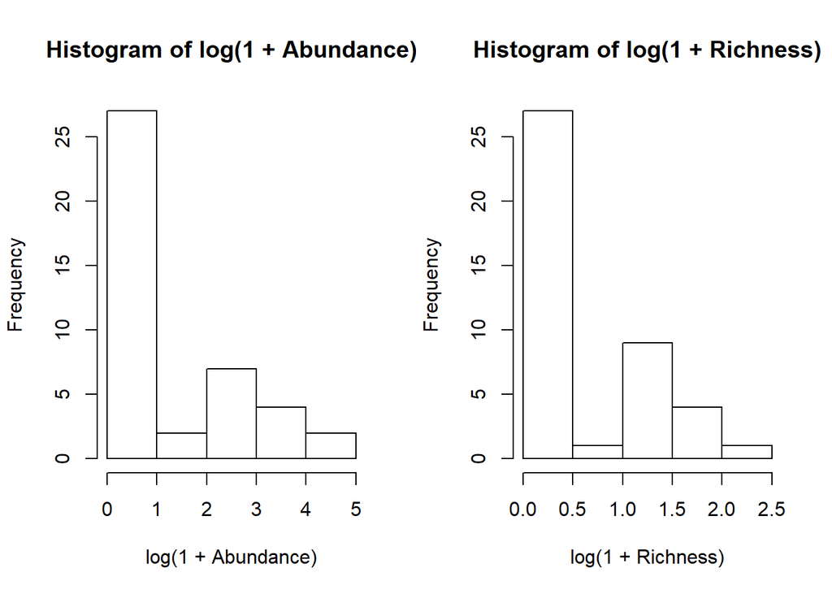

```r
par(mfrow=c(1,2))
hist(log(1+Abundance))
hist(log(1+Richness))
```

Result: log transformation helped for much, but not all variables. Not for height and shifted the substrate variables from left to right. Other transformations (square, antilog, reciprocal) did not give satifying results. For sand and rock (unfortunately) square root worked best.

```r
#tezr= transformed ezr
tezr<-ezr %>% mutate(dep=log(dep), wid=log(wid), Abundance=log(1+Abundance), Richness=log(1+Richness))
```

```r
ezr.pool<-select(ezr, dep, wid, leng, vol, height, savr, pevr)
```

```r
ezr.sub<-select(ezr, sand, rock, peb, alg, rug, rugp)
```

```r
ezr.abri<-select(ezr, savr, pevr, Abundance, Richness)
```

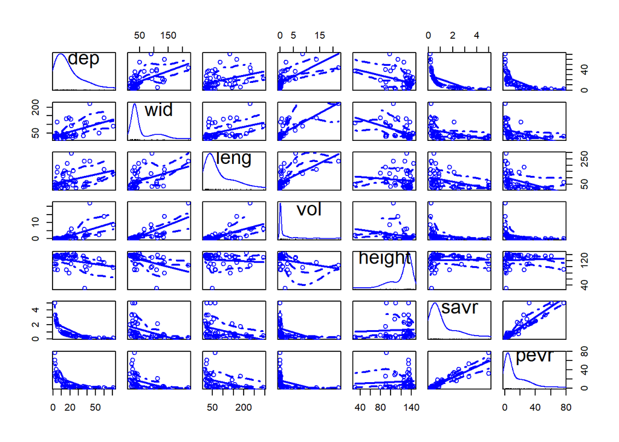

```r
scatterplotMatrix(x=ezr.pool, diagonal='boxplot')
```

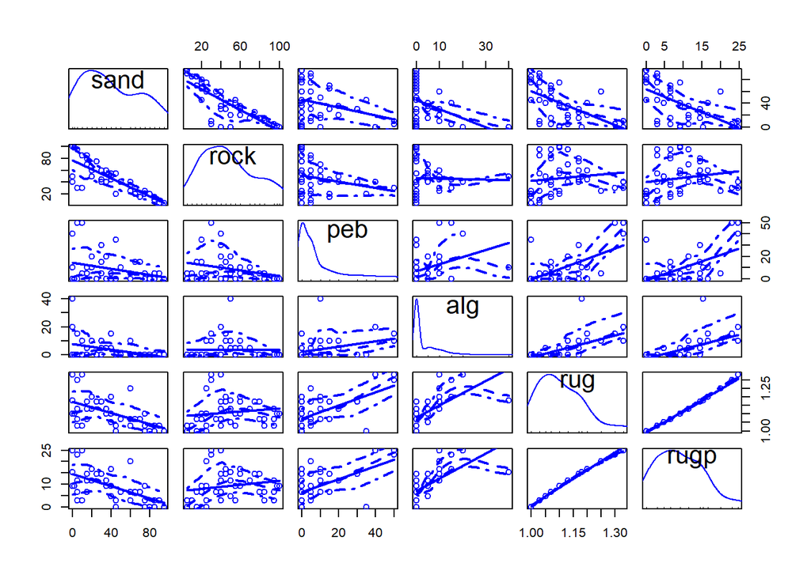

```r
scatterplotMatrix(x=ezr.sub, diagonal='boxplot')
```

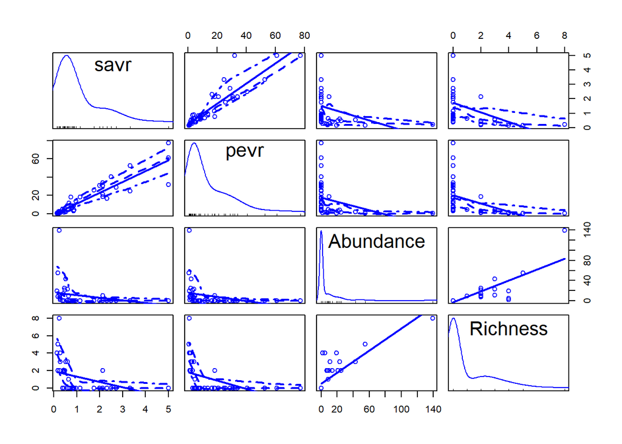

```r
scatterplotMatrix(x=ezr.abri, diagonal='boxplot')
```